# Empirical CDF and Inverse Transform Sampling (Inverse CDF Method)

Statistical Computing for Data Analysis

# The Simulation Problem

**Moving beyond built-in `r` functions**

- R has convenient functions like `rnorm()` and `rpois()`. But what if you are utilizing a distribution that does not have a built-in `R` distribution? Or more realistically, you have a complex piecewise distribution, where no `R` function exists?
- If you can calculate the distribution’s quantile function (the inverse-CDF, $F^{-1}$), you can generate random data for it using the **Inverse Transfom Method** (also known as the Inverse CDF Method).

# Inverse Transform Method (High-level)

**Generating data via quantiles**

Idea is that instead of trying to draw $X$ directly, we generate a random *probability* and work backward to find the corresponding $X$.

**The Algorithm:** 1. Draw a random probability $U$ from a Uniform(0, 1) distribution. (Every probability from 0% to 100% has an equal chance of being selected). 2. Plug $U$ into the inverse-CDF (quantile function). 3. The result is a random draw $X$:
$$X =
F^{-1}(U)$$

Let’s walk through each of these systematically.

# 1. The Uniform(0,1) Distribution

**The Foundation of Randomness**

Before we map probabilities to data, we must understand the Uniform(0,1) distribution: $U \sim \text{Uniform}(0,1)$. - It means every real number between 0 and 1 has an exactly equal chance of being drawn. - The density function $f(x)$ is a flat horizontal line at $y=1$.

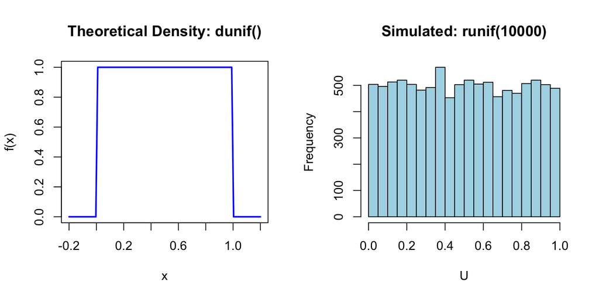

```r
set.seed(4279)
par(mfrow = c(1, 2))

# 1. Theoretical Density (Flat line)
curve(dunif(x), from = -0.2, to = 1.2, lwd = 2, col = "blue",
      main = "Theoretical Density: dunif()", ylab = "f(x)")

# 2. Simulated Draws (Flat histogram)
hist(runif(10000), breaks = 20, col = "lightblue",
     main = "Simulated: runif(10000)", xlab = "U")
```

# 2. My Claim:

2. Plug $U$ into the inverse-CDF (quantile function).
3. The result is a random draw $X$:
   $$X = F^{-1}(U)$$

Why does this work? Because of **Probability Integral Transform.**

# Probability Integral Transform (PIT)

The PIT states that if you plug random data $X$ into its own CDF $F(X)$, the resulting values will be uniformly distributed! Why?

- Think of the CDF, $F(X)$, as calculating a percentile rank.
- Suppose $X$ represents human heights (which are normally distributed, mostly clustered around the mean).If you randomly select a person from the population, are they more likely to be at the 50th percentile or the 90th percentile?
- **Neither.** Any randomly chosen individual is equally likely to land at any specific percentile. The percentiles themselves are uniformly spread from 0 to 1, even if the underlying heights are bunched up in the middle.

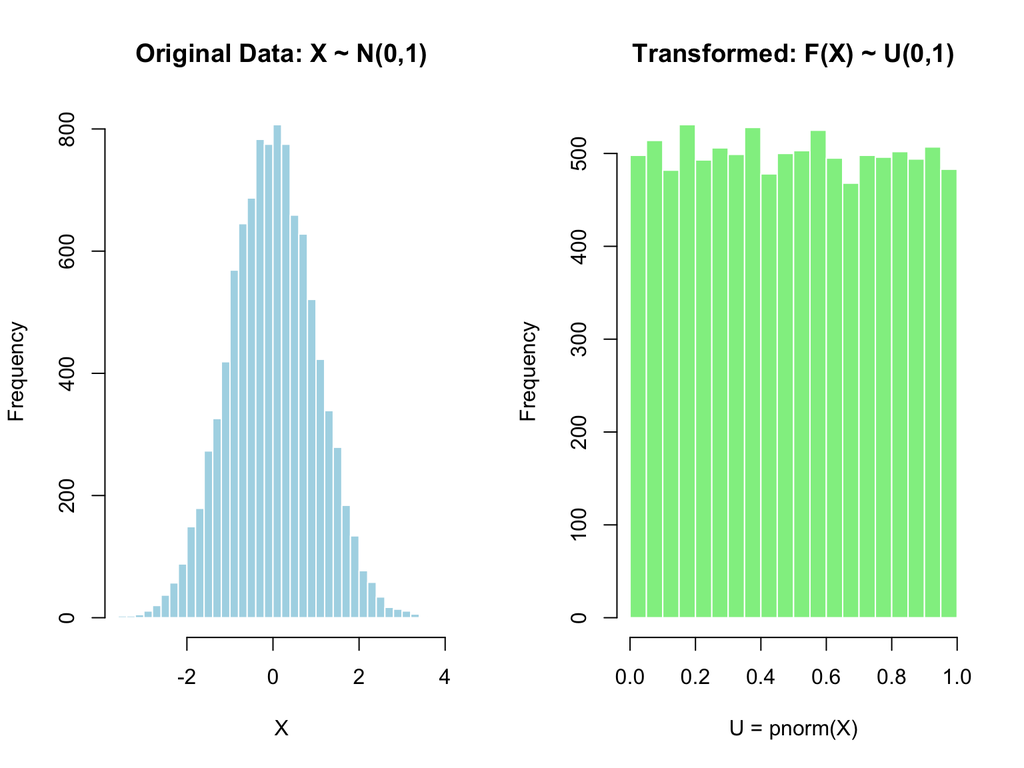

```r
# Set seed for reproducibility
set.seed(4279)

# 1. Generate 10,000 observations from a Standard Normal distribution
X <- rnorm(10000, mean = 0, sd = 1)

# 2. Apply the CDF to the simulated data
U <- pnorm(X, mean = 0, sd = 1)

# 3. Visualize the transformation
par(mfrow = c(1, 2))

# The original data is clustered around the mean
hist(X, breaks = 30, col = "lightblue", border = "white",
     main = "Original Data: X ~ N(0,1)", xlab = "X")

# The transformed data is perfectly flat
hist(U, breaks = 30, col = "lightgreen", border = "white",
     main = "Transformed: F(X) ~ U(0,1)", xlab = "U = pnorm(X)")
```

# The Inverse Transform Sampling Method: Reversing the PIT

If $F(X)$ maps data to a uniform probability $U$, then the inverse function $F^{-1}(U)$ maps a uniform probability back to the data:

$$\begin{align*}
U & = F(X) \\
F^{-1}(U) & = X
\end{align*}$$

This is exactly what our algorithm says:

1. Generate a random probability $U \sim \text{Uniform}(0, 1)$
2. Plug $U$ into the inverse-CDF (quantile function).
3. The result is a random draw $X$:
   $$X =
   F^{-1}(U)$$

# Inverse Transform Sampling Method in R

**Proving the concept with the Normal Distribution**

We can simulate normal data using only `runif()` and `qnorm()`. This is exactly how many statistical software packages generate random variables under the hood.

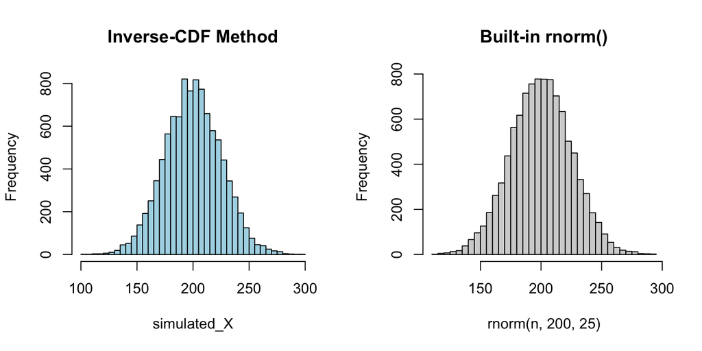

```r
set.seed(4279)
n <- 10000

# 1. Generate 10,000 uniform random probabilities
U <- runif(n, min = 0, max = 1)

# 2. Map them through the inverse-CDF (quantile function)
simulated_X <- qnorm(U, mean = 200, sd = 25)

# 3. Compare to the built-in rnorm
par(mfrow = c(1, 2))
hist(simulated_X, main = "Inverse-CDF Method", col = "lightblue", breaks = 30)
hist(rnorm(n, 200, 25), main = "Built-in rnorm()", col = "lightgray", breaks = 30)
```

# When do we need the Inverse-CDF Method?

**Simulating Custom Distributions**

Base R provides `rnorm`, `rpois`, etc. But what if you are modeling extreme wealth using the Pareto distribution? Base R does not have an `rpareto()` function. You must build it yourself.

1. **Theoretical CDF**: $F(x) = 1 - \left(\frac{x_m}{x}\right)^\alpha$(where $x_m$ is the minimum possible value, and $\alpha$ is the shape parameter).
2. Set equal to U and solve for x (The Inverse CDF):
   $$U = 1 - \left(\frac{x_m}{x}\right)^\alpha
   \implies x = \frac{x_m}{(1 - U)^{1/\alpha}}$$

Now, we can translate this exact math into R code to simulate data. Let’s simulate the wealth of 10,000 individuals where the minimum wealth is $x_m = 100$ and $\alpha = 3$.

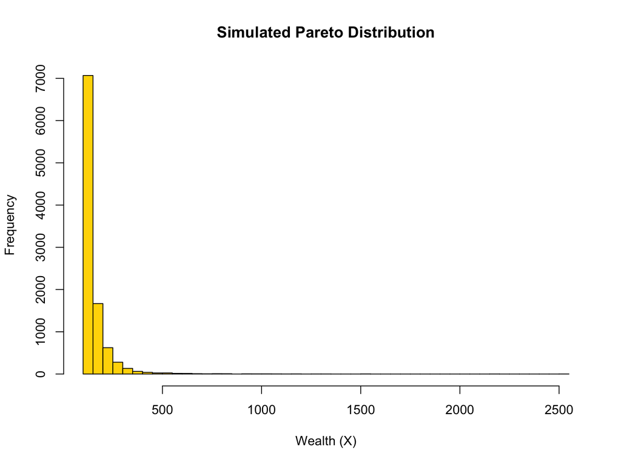

```r
set.seed(4279)

# 1. Generate Uniform(0,1) probabilities
u <- runif(10000)

# 2. Define parameters
x_m <- 100
alpha <- 3

# 3. Apply the Inverse CDF formula
simulated_pareto <- x_m / (1 - u)^(1 / alpha)

# 4. Visualize the heavily right-skewed simulated data
hist(simulated_pareto, breaks = 50, col = "gold",
     main = "Simulated Pareto Distribution", xlab = "Wealth (X)")
```